# The_Effect_of_Candlestick_on_Price_Action

The SPDR S&P 500 trust (SPY) is used for the analysis and subsequent trading strategy of this project, because it comprises 500 large- and mid-cap U.S. stocks. These stocks are selected by a committee based on market size, liquidity, and industry. The S&P 500 serves as one of the main benchmarks of the U.S. equity market and indicates the financial health and stability of the economy (https://www.investopedia.com/articles/investing/122215/spy-spdr-sp-500-trust-etf.asp).

Second-level price data for SPY were extracted from TD Ameritrade, using a wrapper of the broker's API.

The code can be found on my Github profile (https://github.com/GizDave).

Only the week of 5/10/2021 is used to lower the hardware constraint, but the framework should be scalable to a larger quantity of data.

**Questions**

- What does the formation of candles tell us about price action?
- Do the oscillations in the wicks and bodies matter?
- What about the lengths of individual candle parts?
- Can these elements be used to predict price movements?

(From here on, the candles being discussed have the following structure.)

[figure not shown]

```python
import pandas as pd
from datetime import timedelta, datetime
import random
import numpy as np
import matplotlib.pyplot as plt
import warnings
import seaborn as sns

from sklearn.feature_selection import RFE
from sklearn.decomposition import PCA
from sklearn.model_selection import train_test_split
from sklearn.linear_model import LinearRegression
from sklearn.neighbors import KNeighborsRegressor
from sklearn.svm import SVR
from sklearn.metrics import r2_score, mean_squared_error
```

```python
from google.colab import drive
drive.mount('/content/drive')
```

# Setting

```python
# set matplotlib plot size
plt.rcParams['figure.figsize'] = [50, 20]
```

```python
# suppress warnings
warnings.filterwarnings("ignore")
```

# Preprocessing

```python
history = pd.read_excel("/content/drive/My Drive/Systematic Trading Final Project/SPY.xlsx")
```

```python
# Combine DATE and TIMESTAMP
history['TIMESTAMP'] = history.apply(lambda r : pd.datetime.combine(r['DATE'], r['TIMESTAMP']),1)
history.drop(columns='DATE', inplace=True)
```

```python
history.head()
```

|  | TIMESTAMP | BID_PRICE | ASK_PRICE | LAST_PRICE | BID_SIZE | ASK_SIZE | TOTAL_VOLUME | LAST_SIZE | HIGH_PRICE | LOW_PRICE | MID_PRICE | %_FROM_CLOSE_BID | %_FROM_CLOSE_MID | %_FROM_CLOSE_ASK | TWO_MIN_HIGH | TWO_MIN_LOW |
| --- | --- | --- | --- | --- | --- | --- | --- | --- | --- | --- | --- | --- | --- | --- | --- | --- |
| 0 | 2021-05-10 09:30:02 | 422.55 | 422.57 | 422.59 | 6 | 9 | 894057 | 4 | 422.74 | 422.49 | 422.560 | 0.101867 | 0.104236 | 0.106605 | NaN | NaN |
| 1 | 2021-05-10 09:30:03 | 422.54 | 422.55 | 422.54 | 1 | 34 | 899629 | 1 | 422.74 | 422.49 | 422.545 | 0.099498 | 0.100682 | 0.101867 | NaN | NaN |
| 2 | 2021-05-10 09:30:04 | 422.53 | 422.54 | 422.53 | 1 | 11 | 906146 | 1 | 422.74 | 422.49 | 422.535 | 0.097129 | 0.098313 | 0.099498 | NaN | NaN |
| 3 | 2021-05-10 09:30:05 | 422.48 | 422.49 | 422.47 | 1 | 8 | 916518 | 1 | 422.74 | 422.47 | 422.485 | 0.085284 | 0.086468 | 0.087653 | NaN | NaN |
| 4 | 2021-05-10 09:30:06 | 422.45 | 422.47 | 422.46 | 6 | 15 | 942418 | 1 | 422.74 | 422.44 | 422.460 | 0.078177 | 0.080546 | 0.082915 | NaN | NaN |

```python
# check dimension
history.shape
```

```
(114150, 16)
```

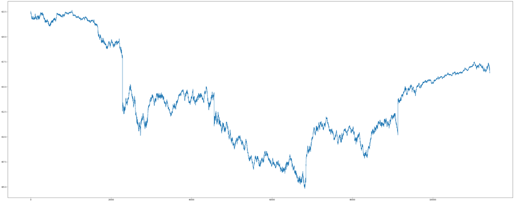

```python
# plot the middle prices between bids and asks
plt.plot(history.MID_PRICE)
```

```python
# check missing value
history.isnull().sum()
```

```
TIMESTAMP             0
BID_PRICE             0
ASK_PRICE             0
LAST_PRICE            0
BID_SIZE              0
ASK_SIZE              0
TOTAL_VOLUME          0
LAST_SIZE             0
HIGH_PRICE            0
LOW_PRICE             0
MID_PRICE             0
%_FROM_CLOSE_BID      0
%_FROM_CLOSE_MID      0
%_FROM_CLOSE_ASK      0
TWO_MIN_HIGH        595
TWO_MIN_LOW         595
dtype: int64
```

```python
# find datetime range
print('from', history.TIMESTAMP.min(), 'to', history.TIMESTAMP.max())
```

```
from 2021-05-10 09:30:02 to 2021-05-14 15:59:59
```

```python
# find number of days
print('{} days in total'.format(history.TIMESTAMP.dt.date.unique().shape[0]))
```

```
5 days in total
```

```python
# check for continuity of datetime
time_gap = history.TIMESTAMP.diff().dt.total_seconds().fillna(0)
print("There are {} time gaps, ranged from {} to {} seconds. {} of which are more than 1 seconds apart and {} are more than 5 seconds apart.".format(int(sum(time_gap)), int(time_gap.min()), int(time_gap.max()), int(sum(time_gap >= 1)), int(sum(time_gap >= 5))))
```

```
There are 368997 time gaps, ranged from 0 to 63002 seconds. 114149 of which are more than 1 seconds apart and 6 are more than 5 seconds apart.
```

The smaller gaps between data entries were due to network delays and the way TD Ameritrade structures it's real-time stream, which only sends new data.

```python
# check daily time ranges
history.groupby(history.TIMESTAMP.dt.date).apply(lambda x: print(x.TIMESTAMP.dt.date.iloc[0], 'from', x.TIMESTAMP.dt.time.min(), 'to', x.TIMESTAMP.dt.time.max()))
```

```
2021-05-10 from 09:30:02 to 16:00:00
2021-05-11 from 09:30:02 to 15:59:59
2021-05-12 from 09:30:01 to 16:00:00
2021-05-13 from 09:30:01 to 16:00:00
2021-05-14 from 09:30:00 to 15:59:59
```

```python
history.set_index(pd.DatetimeIndex(history.TIMESTAMP), inplace=True)
history.drop(columns='TIMESTAMP', inplace=True)
```

# Analysis

```python
history_core = history.drop(columns=['%_FROM_CLOSE_BID', '%_FROM_CLOSE_MID', '%_FROM_CLOSE_ASK', 'TWO_MIN_HIGH', 'TWO_MIN_LOW'])
```

## Candle Creation

```python
# create candles
def makeCandles(window):
  candles = history_core.copy()
  candles['HIGH_PRICE'] = candles.MID_PRICE
  candles['OPEN_PRICE'] = candles.MID_PRICE
  candles['CLOSE_PRICE'] = candles.MID_PRICE
  candles['LOW_PRICE'] = candles.MID_PRICE

  return candles.groupby(candles.index.date).resample(window).agg({
      # candle components
      'HIGH_PRICE': lambda x: x.max(),
      'OPEN_PRICE': lambda x: x.head(1),
      'CLOSE_PRICE': lambda x: x.tail(1),
      'LOW_PRICE': lambda x: x.min(),
      # custom components
      'BID_PRICE': lambda x: x.mean(),
      'ASK_PRICE': lambda x: x.mean(),
      'BID_SIZE': lambda x: x.sum(),
      'ASK_SIZE': lambda x: x.sum()
  }).droplevel(0)
```

```python
# calculate the time spent in wicks and in the body
def getTime(candle):
  row = pd.Series({
    'BODY_TIME': candle[
      (candle.MID_PRICE >= candle[['CLOSE_PRICE', 'OPEN_PRICE']].min(axis=1)) &
      (candle.MID_PRICE <= candle[['CLOSE_PRICE', 'OPEN_PRICE']].max(axis=1))
    ].TIMESTAMP.count(),
    'UPPER_WICK_TIME': candle[
      (candle.MID_PRICE > candle[['CLOSE_PRICE', 'OPEN_PRICE']].max(axis=1)) &
      (candle.MID_PRICE <= candle.HIGH_PRICE)
    ].TIMESTAMP.count(),
    'LOWER_WICK_TIME': candle[
      (candle.MID_PRICE < candle[['CLOSE_PRICE', 'OPEN_PRICE']].min(axis=1)) &
      (candle.MID_PRICE >= candle.LOW_PRICE)
     ].TIMESTAMP.count()
  })

  return row

def getTimes(candles):
  history_core['temp'] = history_core.index.to_series().apply(lambda t: t.replace(second=0))
  temp = history_core.reset_index()[['temp', 'TIMESTAMP', 'MID_PRICE']].merge(
    candles[['HIGH_PRICE', 'OPEN_PRICE', 'CLOSE_PRICE', 'LOW_PRICE']],
    left_on = history_core.temp,
    right_on = candles.index
  ).drop(columns=['key_0'])
  candles_time = temp.groupby(temp['temp']).apply(lambda x: getTime(x))

  candles['BODY_TIME'] = candles_time['BODY_TIME']
  candles['UPPER_WICK_TIME'] = candles_time['UPPER_WICK_TIME']
  candles['LOWER_WICK_TIME'] = candles_time['LOWER_WICK_TIME']
```

```python
# calculate body lengths, wick lengths
def getLengths(candles):
  candles['HEIGHT'] = candles['HIGH_PRICE'] - candles['LOW_PRICE']
  candles['HEIGHT_CHG'] = candles['HEIGHT'].diff()
  candles['BODY_LEN'] = abs(candles.CLOSE_PRICE - candles.OPEN_PRICE)
  candles['UPPER_WICK_LEN'] = candles.apply(lambda x: x.HIGH_PRICE - x.CLOSE_PRICE if x.CLOSE_PRICE > x.OPEN_PRICE else x.HIGH_PRICE - x.OPEN_PRICE, axis=1)
  candles['LOWER_WICK_LEN'] = candles.apply(lambda x: x.CLOSE_PRICE - x.LOW_PRICE if x.CLOSE_PRICE < x.OPEN_PRICE else x.OPEN_PRICE - x.LOW_PRICE, axis=1)
```

```python
# normalize based on candle height
def normLengths(candles):
  candles['BODY_LEN'] = candles['BODY_LEN'] / candles['HEIGHT']
  candles['BODY_LEN_CHG'] = candles['BODY_LEN'].diff()
  candles['UPPER_WICK_LEN'] = candles['UPPER_WICK_LEN'] / candles['HEIGHT']
  candles['UPPER_WICK_LEN_CHG'] = candles['UPPER_WICK_LEN'].diff()
  candles['LOWER_WICK_LEN'] = candles['LOWER_WICK_LEN'] / candles['HEIGHT']
  candles['LOWER_WICK_LEN_CHG'] = candles['LOWER_WICK_LEN'].diff()
```

```python
# calculate wick ratios relative to the bodies
def getRatios(candles):
  candles['UPPER_WICK_RATIO'] = candles['UPPER_WICK_LEN'] / candles['BODY_LEN'] # upper wick to body
  candles['UPPER_WICK_RATIO_CHG'] = candles['UPPER_WICK_RATIO'].diff()
  candles['LOWER_WICK_RATIO'] = candles['LOWER_WICK_LEN'] / candles['BODY_LEN'] # lower wick to body
  candles['LOWER_WICK_RATIO_CHG'] = candles['LOWER_WICK_RATIO'].diff()
  candles['WICK_RATIO'] = (candles['UPPER_WICK_LEN'] + candles['LOWER_WICK_LEN']) / candles['BODY_LEN'] # wick to body
  candles['WICK_RATIO_CHG'] = candles['WICK_RATIO'].diff()
```

```python
# calculate returns
def getReturns(candles):
  # assume the open price matches the actual previous close price
  candles['return'] = (candles['CLOSE_PRICE'] - candles['OPEN_PRICE']) / candles['OPEN_PRICE']
```

```python
def wrapper(timeframe):
  candles = makeCandles(timeframe)
  getLengths(candles)
  normLengths(candles)
  getRatios(candles)
  getTimes(candles)
  getReturns(candles)
  candles.replace([np.inf, -np.inf], np.nan, inplace=True)
  return candles
```

```python
# create candles with proposed features using 3 different time frames

# 30s
candles_30s = wrapper('30S')

# 1min
candles_1min = wrapper("1Min")

# 5min
candles_5min = wrapper('5Min')
```

## Descriptive Statistics

```python
candles_30s.describe()
```

|  | HIGH_PRICE | OPEN_PRICE | CLOSE_PRICE | LOW_PRICE | BID_PRICE | ASK_PRICE | BID_SIZE | ASK_SIZE | HEIGHT | HEIGHT_CHG | BODY_LEN | UPPER_WICK_LEN | LOWER_WICK_LEN | BODY_LEN_CHG | UPPER_WICK_LEN_CHG | LOWER_WICK_LEN_CHG | UPPER_WICK_RATIO | UPPER_WICK_RATIO_CHG | LOWER_WICK_RATIO | LOWER_WICK_RATIO_CHG | WICK_RATIO | WICK_RATIO_CHG | BODY_TIME | UPPER_WICK_TIME | LOWER_WICK_TIME | return |
| --- | --- | --- | --- | --- | --- | --- | --- | --- | --- | --- | --- | --- | --- | --- | --- | --- | --- | --- | --- | --- | --- | --- | --- | --- | --- | --- |
| count | 3903.000000 | 3903.000000 | 3903.000000 | 3903.000000 | 3903.000000 | 3903.000000 | 3903.000000 | 3903.000000 | 3903.000000 | 3902.000000 | 3900.000000 | 3900.000000 | 3900.000000 | 3896.000000 | 3896.000000 | 3896.000000 | 3731.000000 | 3571.000000 | 3731.000000 | 3571.000000 | 3731.000000 | 3571.000000 | 1953.000000 | 1953.000000 | 1953.000000 | 3.903000e+03 |
| mean | 413.912264 | 413.838784 | 413.838815 | 413.765629 | 413.833766 | 413.844231 | 238.792980 | 238.524981 | 0.146635 | 0.000068 | 0.552050 | 0.224694 | 0.223256 | -0.000233 | 0.000278 | -0.000045 | 0.909170 | -0.000340 | 0.860811 | -0.000493 | 1.769981 | -0.000833 | 29.301587 | 8.576037 | 9.055300 | 1.495136e-07 |
| std | 4.640019 | 4.657893 | 4.656659 | 4.674648 | 4.657661 | 4.657407 | 151.428744 | 127.505521 | 0.088526 | 0.090121 | 0.295412 | 0.238046 | 0.239071 | 0.418903 | 0.338852 | 0.337056 | 2.138452 | 2.959700 | 1.840998 | 2.629372 | 3.198911 | 4.470194 | 14.122694 | 10.610536 | 10.961511 | 2.907099e-04 |
| min | 405.075000 | 404.865000 | 404.845000 | 404.815000 | 404.961724 | 404.971034 | 2.000000 | 4.000000 | 0.000000 | -0.560000 | 0.000000 | 0.000000 | 0.000000 | -1.000000 | -1.000000 | -1.000000 | 0.000000 | -33.909091 | 0.000000 | -37.000000 | 0.000000 | -38.840000 | 1.000000 | 0.000000 | 0.000000 | -1.475444e-03 |
| 25% | 410.505000 | 410.400000 | 410.395000 | 410.315000 | 410.410517 | 410.421034 | 161.000000 | 166.000000 | 0.080000 | -0.050000 | 0.307692 | 0.000000 | 0.000000 | -0.290625 | -0.212674 | -0.200000 | 0.000000 | -0.500000 | 0.000000 | -0.500000 | 0.239718 | -1.000000 | 19.000000 | 0.000000 | 0.000000 | -1.476144e-04 |
| 50% | 413.715000 | 413.635000 | 413.625000 | 413.545000 | 413.625333 | 413.635333 | 206.000000 | 209.000000 | 0.130000 | 0.000000 | 0.571429 | 0.155048 | 0.153846 | -0.008368 | 0.000000 | 0.000000 | 0.250000 | 0.000000 | 0.250000 | 0.000000 | 0.666667 | 0.029762 | 29.000000 | 4.000000 | 5.000000 | 0.000000e+00 |
| 75% | 416.685000 | 416.660000 | 416.655000 | 416.625000 | 416.660690 | 416.670862 | 271.000000 | 270.000000 | 0.190000 | 0.040000 | 0.800000 | 0.363636 | 0.363636 | 0.305556 | 0.208333 | 0.200000 | 0.904545 | 0.500000 | 1.000000 | 0.500000 | 2.000000 | 1.054174 | 39.000000 | 13.000000 | 14.000000 | 1.449275e-04 |
| max | 422.655000 | 422.605000 | 422.585000 | 422.545000 | 422.577241 | 422.587241 | 2700.000000 | 1699.000000 | 0.670000 | 0.535000 | 1.000000 | 1.000000 | 1.000000 | 1.000000 | 1.000000 | 1.000000 | 47.000000 | 42.000000 | 37.000000 | 36.826087 | 47.000000 | 38.739130 | 59.000000 | 56.000000 | 53.000000 | 1.547474e-03 |

```python
candles_1min.describe()
```

|  | HIGH_PRICE | OPEN_PRICE | CLOSE_PRICE | LOW_PRICE | BID_PRICE | ASK_PRICE | BID_SIZE | ASK_SIZE | HEIGHT | HEIGHT_CHG | BODY_LEN | UPPER_WICK_LEN | LOWER_WICK_LEN | BODY_LEN_CHG | UPPER_WICK_LEN_CHG | LOWER_WICK_LEN_CHG | UPPER_WICK_RATIO | UPPER_WICK_RATIO_CHG | LOWER_WICK_RATIO | LOWER_WICK_RATIO_CHG | WICK_RATIO | WICK_RATIO_CHG | BODY_TIME | UPPER_WICK_TIME | LOWER_WICK_TIME | return |
| --- | --- | --- | --- | --- | --- | --- | --- | --- | --- | --- | --- | --- | --- | --- | --- | --- | --- | --- | --- | --- | --- | --- | --- | --- | --- | --- |
| count | 1953.000000 | 1953.000000 | 1953.000000 | 1953.000000 | 1953.000000 | 1953.000000 | 1953.000000 | 1953.000000 | 1953.000000 | 1952.000000 | 1950.000000 | 1950.000000 | 1950.000000 | 1946.000000 | 1946.000000 | 1946.000000 | 1888.000000 | 1826.000000 | 1888.000000 | 1826.000000 | 1888.000000 | 1.826000e+03 | 1953.000000 | 1953.000000 | 1953.000000 | 1953.000000 |
| mean | 413.946900 | 413.834616 | 413.833597 | 413.725120 | 413.831779 | 413.842244 | 477.219150 | 476.683564 | 0.221779 | 0.000156 | 0.527067 | 0.240775 | 0.232158 | -0.000177 | 0.000332 | -0.000156 | 1.147848 | -0.001733 | 1.063444 | -0.012250 | 2.211292 | -1.398272e-02 | 33.747568 | 12.691756 | 12.009217 | -0.000002 |
| std | 4.632613 | 4.662569 | 4.660655 | 4.684896 | 4.658970 | 4.658717 | 269.134732 | 221.963825 | 0.126499 | 0.127378 | 0.285870 | 0.229702 | 0.228140 | 0.407936 | 0.322575 | 0.318911 | 2.513516 | 3.522569 | 2.486396 | 3.576864 | 4.166570 | 5.922937e+00 | 16.634458 | 14.402556 | 13.976998 | 0.000412 |
| min | 405.185000 | 404.865000 | 404.845000 | 404.815000 | 405.019492 | 405.029661 | 2.000000 | 4.000000 | 0.000000 | -0.690000 | 0.000000 | 0.000000 | 0.000000 | -1.000000 | -0.964286 | -0.854312 | 0.000000 | -26.785714 | 0.000000 | -38.000000 | 0.000000 | -5.086885e+01 | 1.000000 | 0.000000 | 0.000000 | -0.001953 |
| 25% | 410.545000 | 410.395000 | 410.395000 | 410.245000 | 410.411864 | 410.422034 | 329.000000 | 342.000000 | 0.130000 | -0.060000 | 0.285714 | 0.043478 | 0.030303 | -0.285566 | -0.188254 | -0.187500 | 0.052632 | -0.600000 | 0.033065 | -0.523539 | 0.285714 | -1.188910e+00 | 20.000000 | 1.000000 | 1.000000 | -0.000232 |
| 50% | 413.775000 | 413.615000 | 413.615000 | 413.495000 | 413.630172 | 413.640345 | 420.000000 | 425.000000 | 0.200000 | 0.000000 | 0.540064 | 0.181818 | 0.166667 | 0.000000 | 0.000000 | 0.000000 | 0.303846 | 0.000000 | 0.285714 | 0.000000 | 0.800000 | -6.158962e-13 | 35.000000 | 7.000000 | 6.000000 | 0.000000 |
| 75% | 416.705000 | 416.665000 | 416.655000 | 416.605000 | 416.658475 | 416.668983 | 541.000000 | 546.000000 | 0.285000 | 0.060000 | 0.772727 | 0.380952 | 0.380952 | 0.300000 | 0.193316 | 0.200000 | 1.000000 | 0.600000 | 1.000000 | 0.600000 | 2.188244 | 1.223952e+00 | 49.000000 | 20.000000 | 19.000000 | 0.000225 |
| max | 422.655000 | 422.560000 | 422.555000 | 422.495000 | 422.550172 | 422.560345 | 4756.000000 | 3037.000000 | 1.020000 | 0.750000 | 1.000000 | 1.000000 | 1.000000 | 1.000000 | 0.966667 | 1.000000 | 27.500000 | 26.700000 | 38.000000 | 38.000000 | 51.000000 | 5.066667e+01 | 59.000000 | 57.000000 | 57.000000 | 0.002265 |

```python
candles_5min.describe()
```

|  | HIGH_PRICE | OPEN_PRICE | CLOSE_PRICE | LOW_PRICE | BID_PRICE | ASK_PRICE | BID_SIZE | ASK_SIZE | HEIGHT | HEIGHT_CHG | BODY_LEN | UPPER_WICK_LEN | LOWER_WICK_LEN | BODY_LEN_CHG | UPPER_WICK_LEN_CHG | LOWER_WICK_LEN_CHG | UPPER_WICK_RATIO | UPPER_WICK_RATIO_CHG | LOWER_WICK_RATIO | LOWER_WICK_RATIO_CHG | WICK_RATIO | WICK_RATIO_CHG | BODY_TIME | UPPER_WICK_TIME | LOWER_WICK_TIME | return |
| --- | --- | --- | --- | --- | --- | --- | --- | --- | --- | --- | --- | --- | --- | --- | --- | --- | --- | --- | --- | --- | --- | --- | --- | --- | --- | --- |
| count | 393.000000 | 393.000000 | 393.000000 | 393.000000 | 393.000000 | 393.000000 | 393.000000 | 393.000000 | 393.000000 | 392.000000 | 390.000000 | 390.000000 | 390.000000 | 386.000000 | 3.860000e+02 | 386.000000 | 385.000000 | 376.000000 | 385.000000 | 376.000000 | 385.000000 | 376.000000 | 393.000000 | 393.000000 | 393.000000 | 393.000000 |
| mean | 414.085891 | 413.823041 | 413.818422 | 413.549644 | 413.816086 | 413.826548 | 2371.524173 | 2368.862595 | 0.536247 | 0.000548 | 0.501899 | 0.245109 | 0.252993 | 0.000752 | -1.136743e-03 | 0.000385 | 2.014606 | -0.018312 | 2.029546 | 0.051897 | 4.044152 | 0.033585 | 31.366412 | 13.173028 | 13.597964 | -0.000010 |
| std | 4.603828 | 4.685288 | 4.677377 | 4.737363 | 4.669384 | 4.669133 | 1049.444822 | 866.786124 | 0.276526 | 0.287596 | 0.284250 | 0.221525 | 0.226456 | 0.391483 | 3.068216e-01 | 0.296287 | 5.573290 | 7.939948 | 5.780888 | 7.955440 | 9.359199 | 13.233041 | 20.277994 | 18.224943 | 18.588212 | 0.000959 |
| min | 405.525000 | 404.865000 | 404.845000 | 404.815000 | 405.228874 | 405.239078 | 2.000000 | 4.000000 | 0.000000 | -1.240000 | 0.000000 | 0.000000 | 0.000000 | -0.840000 | -8.598100e-01 | -0.848165 | 0.000000 | -52.533333 | 0.000000 | -60.066667 | 0.000000 | -61.333333 | 1.000000 | 0.000000 | 0.000000 | -0.002826 |
| 25% | 410.675000 | 410.345000 | 410.275000 | 410.095000 | 410.381712 | 410.391678 | 1723.000000 | 1804.000000 | 0.320000 | -0.160000 | 0.250000 | 0.067797 | 0.057149 | -0.265482 | -1.666667e-01 | -0.175482 | 0.111111 | -0.605082 | 0.083333 | -0.610795 | 0.333333 | -1.662371 | 12.000000 | 0.000000 | 0.000000 | -0.000533 |
| 50% | 413.965000 | 413.615000 | 413.615000 | 413.275000 | 413.597713 | 413.608089 | 2161.000000 | 2220.000000 | 0.510000 | 0.000000 | 0.528857 | 0.181361 | 0.206924 | 0.017329 | -9.658940e-15 | 0.000000 | 0.384615 | -0.013034 | 0.413793 | 0.000000 | 0.872340 | -0.053774 | 33.000000 | 2.000000 | 2.000000 | 0.000000 |
| 75% | 416.805000 | 416.665000 | 416.675000 | 416.515000 | 416.677363 | 416.687603 | 2743.000000 | 2740.000000 | 0.720000 | 0.140000 | 0.747145 | 0.375000 | 0.389905 | 0.262563 | 1.651188e-01 | 0.200158 | 1.136364 | 0.621269 | 1.384615 | 0.591223 | 2.846154 | 1.230769 | 51.000000 | 24.000000 | 24.000000 | 0.000536 |
| max | 422.655000 | 422.560000 | 422.555000 | 422.385000 | 422.444949 | 422.454949 | 10298.000000 | 6641.000000 | 1.620000 | 1.290000 | 1.000000 | 0.979592 | 0.954545 | 0.861158 | 9.232656e-01 | 0.738046 | 53.000000 | 52.804878 | 63.000000 | 62.584615 | 65.000000 | 64.523077 | 59.000000 | 58.000000 | 58.000000 | 0.002864 |

Some observations

- Shorter time frames capture more short-term moves, which make the wicks relatively shorter than those of the longer time frames.
- Shorter time frames seem to suggest a relatively more consistent height.
  - It might be helpful to use shorter time frame as a reference.

## Variable Correlation

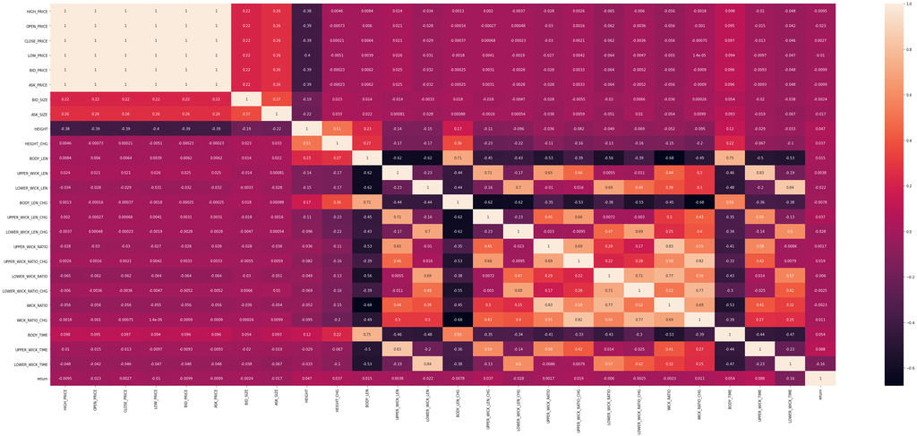

```python
sns.heatmap(candles_30s.corr(), annot=True)
```

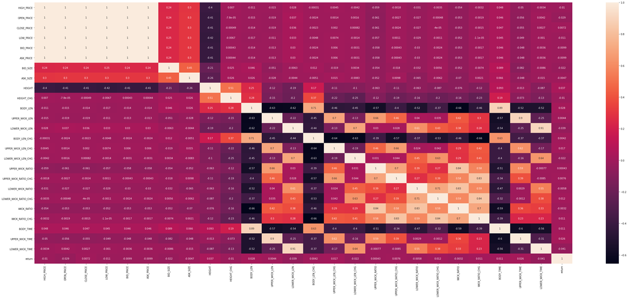

```python
sns.heatmap(candles_1min.corr(), annot=True)
```

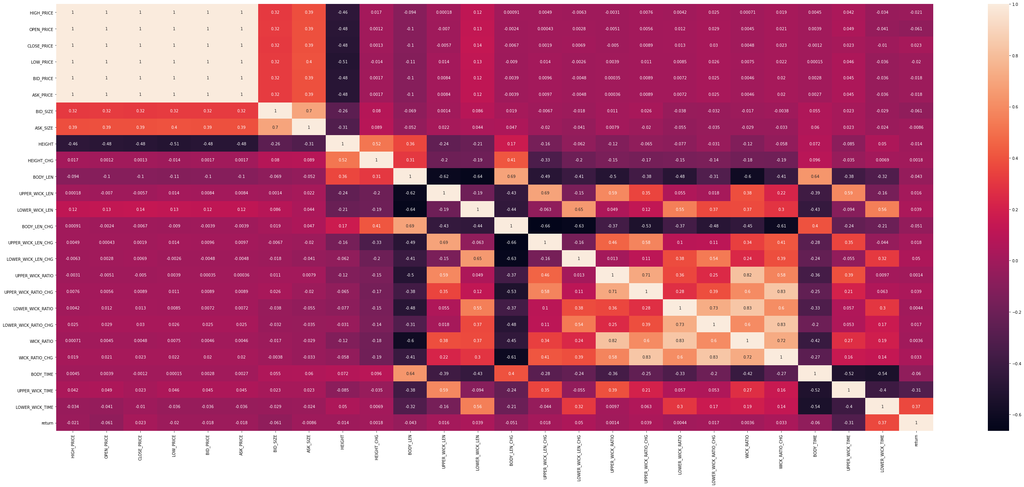

```python
sns.heatmap(candles_5min.corr(), annot=True)
```

## Multivariate Analysis

Variables are not scaled because the distribution is not known, but note the large differences between the variables' variances, especially between those of bid/ask sizes and others, which will influence the results of PCA.

There are missing values inside the dataframes, but imputations are not performed to preserve the data. Instead, the rows with missing values are dropped.

```python
core_features = [
  'HIGH_PRICE', 'OPEN_PRICE', 'CLOSE_PRICE', 'LOW_PRICE', 'BID_PRICE',
  'ASK_PRICE', 'BID_SIZE', 'ASK_SIZE'
]

extra_features = [
  'HEIGHT', 'HEIGHT_CHG', 'BODY_LEN',
  'UPPER_WICK_LEN', 'LOWER_WICK_LEN', 'BODY_LEN_CHG',
  'UPPER_WICK_LEN_CHG', 'LOWER_WICK_LEN_CHG', 'UPPER_WICK_RATIO',
  'UPPER_WICK_RATIO_CHG', 'LOWER_WICK_RATIO', 'LOWER_WICK_RATIO_CHG',
  'WICK_RATIO', 'WICK_RATIO_CHG', 'BODY_TIME', 'UPPER_WICK_TIME',
  'LOWER_WICK_TIME'
]
```

```python
def pca_summary(pca, data):
    names = data.columns
    a = list(np.std(pca.transform(data), axis=0))
    b = list(pca.explained_variance_ratio_)
    c = [np.sum(pca.explained_variance_ratio_[:i]) for i in range(1, len(pca.explained_variance_ratio_)+1)]
    summary = pd.DataFrame(zip(a, b, c), index=names, columns=["Std", "Explained Variance", "Cumulative Variance"])
    summary['Explained Variance'] = summary['Explained Variance'].round(decimals=4)
    display(summary)
```

```python
def elbow(pca, data):
    y = np.std(pca.transform(data), axis=0)**2
    x = np.arange(len(y)) + 1
    plt.plot(x, y, "o-")
    plt.xticks(x, [str(i) for i in x], rotation=60)
    plt.ylabel("Variance")
    plt.show()
```

Use Principal Component Analysis to find what features to use.

|  | Std | Explained Variance | Cumulative Variance |
| --- | --- | --- | --- |
| HEIGHT | 1.598412e+01 | 0.5462 | 0.546232 |
| HEIGHT_CHG | 1.185560e+01 | 0.3005 | 0.846734 |
| BODY_LEN | 5.889774e+00 | 0.0742 | 0.920899 |
| UPPER_WICK_LEN | 4.984363e+00 | 0.0531 | 0.974014 |
| LOWER_WICK_LEN | 2.488565e+00 | 0.0132 | 0.987254 |
| BODY_LEN_CHG | 2.213306e+00 | 0.0105 | 0.997727 |
| UPPER_WICK_LEN_CHG | 9.382435e-01 | 0.0019 | 0.999610 |
| LOWER_WICK_LEN_CHG | 3.099779e-01 | 0.0002 | 0.999815 |
| UPPER_WICK_RATIO | 2.165020e-01 | 0.0001 | 0.999915 |
| UPPER_WICK_RATIO_CHG | 1.344624e-01 | 0.0000 | 0.999954 |
| LOWER_WICK_RATIO | 9.964532e-02 | 0.0000 | 0.999975 |
| LOWER_WICK_RATIO_CHG | 9.097663e-02 | 0.0000 | 0.999993 |
| WICK_RATIO | 5.831369e-02 | 0.0000 | 1.000000 |
| WICK_RATIO_CHG | 1.535517e-15 | 0.0000 | 1.000000 |
| BODY_TIME | 1.326856e-15 | 0.0000 | 1.000000 |
| UPPER_WICK_TIME | 7.511327e-16 | 0.0000 | 1.000000 |
| LOWER_WICK_TIME | 1.237031e-15 | 0.0000 | 1.000000 |

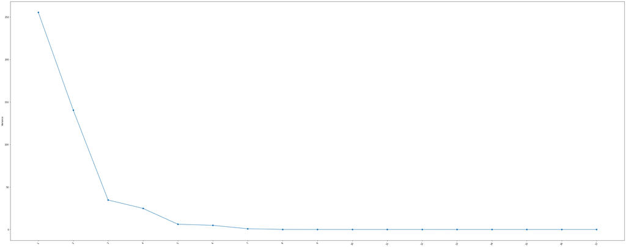

```python
pca_30s = PCA().fit(candles_30s[extra_features].dropna())
pca_summary(pca_30s, candles_30s[extra_features].dropna())
elbow(pca_30s, candles_30s[extra_features].dropna())
```

Elbow appears at 3.

|  | Std | Explained Variance | Cumulative Variance |
| --- | --- | --- | --- |
| HEIGHT | 2.040586e+01 | 0.5624 | 0.562351 |
| HEIGHT_CHG | 1.599553e+01 | 0.3455 | 0.907888 |
| BODY_LEN | 7.127039e+00 | 0.0686 | 0.976487 |
| UPPER_WICK_LEN | 2.935421e+00 | 0.0116 | 0.988124 |
| LOWER_WICK_LEN | 2.681775e+00 | 0.0097 | 0.997837 |
| BODY_LEN_CHG | 1.117581e+00 | 0.0017 | 0.999523 |
| UPPER_WICK_LEN_CHG | 4.133369e-01 | 0.0002 | 0.999754 |
| LOWER_WICK_LEN_CHG | 3.025251e-01 | 0.0001 | 0.999878 |
| UPPER_WICK_RATIO | 2.020379e-01 | 0.0001 | 0.999933 |
| UPPER_WICK_RATIO_CHG | 1.525549e-01 | 0.0000 | 0.999964 |
| LOWER_WICK_RATIO | 1.135975e-01 | 0.0000 | 0.999982 |
| LOWER_WICK_RATIO_CHG | 8.411940e-02 | 0.0000 | 0.999991 |
| WICK_RATIO | 8.084266e-02 | 0.0000 | 1.000000 |
| WICK_RATIO_CHG | 2.009754e-15 | 0.0000 | 1.000000 |
| BODY_TIME | 1.265169e-15 | 0.0000 | 1.000000 |
| UPPER_WICK_TIME | 4.417235e-16 | 0.0000 | 1.000000 |
| LOWER_WICK_TIME | 1.814388e-15 | 0.0000 | 1.000000 |

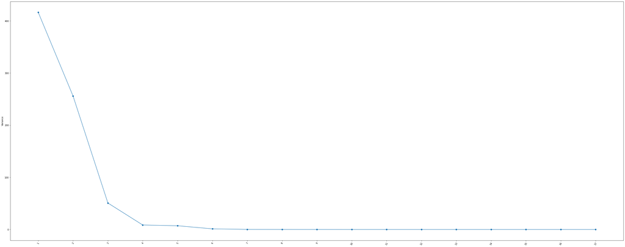

```python
pca_1min = PCA().fit(candles_1min[extra_features].dropna())
pca_summary(pca_1min, candles_1min[extra_features].dropna())
elbow(pca_1min, candles_1min[extra_features].dropna())
```

Elbow appears at 3.

|  | Std | Explained Variance | Cumulative Variance |
| --- | --- | --- | --- |
| HEIGHT | 2.552677e+01 | 0.5624 | 0.562351 |
| HEIGHT_CHG | 2.187737e+01 | 0.3455 | 0.907888 |
| BODY_LEN | 1.700842e+01 | 0.0686 | 0.976487 |
| UPPER_WICK_LEN | 6.618664e+00 | 0.0116 | 0.988124 |
| LOWER_WICK_LEN | 6.993557e+00 | 0.0097 | 0.997837 |
| BODY_LEN_CHG | 2.721865e+00 | 0.0017 | 0.999523 |
| UPPER_WICK_LEN_CHG | 3.017723e-01 | 0.0002 | 0.999754 |
| LOWER_WICK_LEN_CHG | 5.584888e-01 | 0.0001 | 0.999878 |
| UPPER_WICK_RATIO | 4.139616e-01 | 0.0001 | 0.999933 |
| UPPER_WICK_RATIO_CHG | 3.029295e-01 | 0.0000 | 0.999964 |
| LOWER_WICK_RATIO | 2.214028e-01 | 0.0000 | 0.999982 |
| LOWER_WICK_RATIO_CHG | 1.860320e-01 | 0.0000 | 0.999991 |
| WICK_RATIO | 1.924477e-01 | 0.0000 | 1.000000 |
| WICK_RATIO_CHG | 4.072051e-15 | 0.0000 | 1.000000 |
| BODY_TIME | 2.429733e-15 | 0.0000 | 1.000000 |
| UPPER_WICK_TIME | 6.942794e-16 | 0.0000 | 1.000000 |
| LOWER_WICK_TIME | 3.974284e-15 | 0.0000 | 1.000000 |

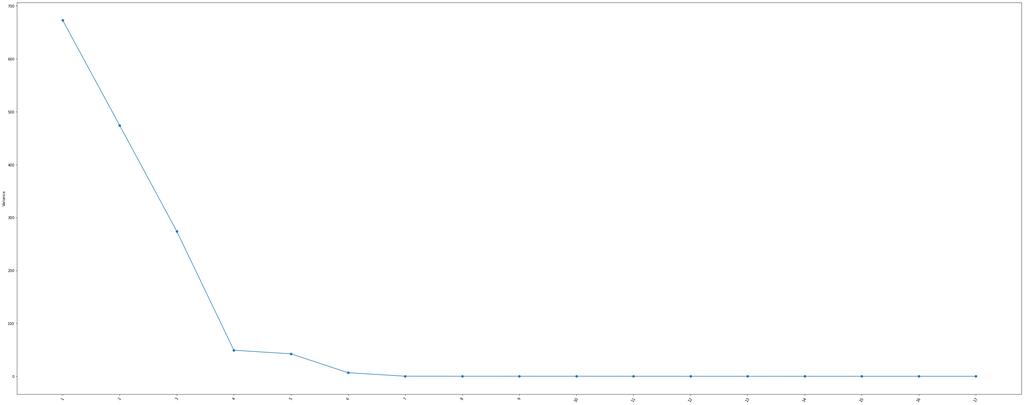

```python
pca_5min = PCA().fit(candles_5min[extra_features].dropna())
pca_summary(pca_1min, candles_5min[extra_features].dropna())
elbow(pca_5min, candles_5min[extra_features].dropna())
```

Elbow appears at 4.

# Modeling

This strategy aims to predict the beginning of breakouts. It's best to be used a warning system of a larger model that incorporates indicators/features for longer-term price action.

```python
history_core.drop(columns="temp", inplace=True)
```

```python
# the price to predict is MID_PRICE = (BID_PRICE + ASK_PRICE)/2
history_core.head()
```

| TIMESTAMP | BID_PRICE | ASK_PRICE | LAST_PRICE | BID_SIZE | ASK_SIZE | TOTAL_VOLUME | LAST_SIZE | HIGH_PRICE | LOW_PRICE | MID_PRICE |
| --- | --- | --- | --- | --- | --- | --- | --- | --- | --- | --- |
| 2021-05-10 09:30:02 | 422.55 | 422.57 | 422.59 | 6 | 9 | 894057 | 4 | 422.74 | 422.49 | 422.560 |
| 2021-05-10 09:30:03 | 422.54 | 422.55 | 422.54 | 1 | 34 | 899629 | 1 | 422.74 | 422.49 | 422.545 |
| 2021-05-10 09:30:04 | 422.53 | 422.54 | 422.53 | 1 | 11 | 906146 | 1 | 422.74 | 422.49 | 422.535 |
| 2021-05-10 09:30:05 | 422.48 | 422.49 | 422.47 | 1 | 8 | 916518 | 1 | 422.74 | 422.47 | 422.485 |
| 2021-05-10 09:30:06 | 422.45 | 422.47 | 422.46 | 6 | 15 | 942418 | 1 | 422.74 | 422.44 | 422.460 |

```python
X = ['HEIGHT', 'HEIGHT_CHG', 'BODY_LEN', 'UPPER_WICK_LEN']
y = ['MID_PRICE']
```

```python
# create train/test datasets
# use candles constructed with time frames from 30s to 5min in 30s increment
s = 30 # seconds
test_size = 0.2

candles_collection = {}

for i in range(10):
  label = '{}Min'.format(s/60)
  df_x = wrapper(label).dropna() # drop rows with missing values
  df_x['MID_PRICE'] = (df_x['HIGH_PRICE'] + df_x['LOW_PRICE'])/2 # might be distorted by long wicks
  df_x = df_x[X + y]
  X_train, X_test, y_train, y_test = train_test_split(df_x[X], df_x[y], test_size=test_size, random_state=None)
  candles_collection[label] = [X_train, X_test, y_train, y_test]
  s = s + 30
```

```python
best_model = {}
```

## Linear Regression

```python
# Linear Regression for baseline comparison
linear_collection = {label: None for label in candles_collection.keys()}

for label, candles in candles_collection.items():
  X_train, X_test, y_train, y_test = candles_collection[label]
  # modeling
  linear = LinearRegression()
  linear.fit(X_train, y_train)
  # record model
  linear_collection[label] = linear
```

## K-Nearest Neighbor

```python
# K-Nearest Neighbor to emulate the breakout system
max_neigh = 10 # limited to 10 for hardware constraints

knn_collection = {label: [] for label in candles_collection.keys()}

for label, candles in candles_collection.items():
  for n in range(1, max_neigh+1):
    X_train, X_test, y_train, y_test = candles_collection[label]
    # modeling
    neigh = KNeighborsRegressor(n_neighbors=n)
    neigh.fit(X_train, y_train)
    # record model
    knn_collection[label].append(neigh)
```

## Support Vector Machine

```python
# Support Vector Machine for regression
svm_collection = {label: None for label in candles_collection.keys()}

for label, candles in candles_collection.items():
  X_train, X_test, y_train, y_test = candles_collection[label]
  # modeling
  svm = SVR()
  svm.fit(X_train, y_train)
  # record model
  svm_collection[label] = svm
```

# Model Evaluation

## Linear Regression

```python
# Linear Regression
linear_collection_mse = {label: [] for label in candles_collection.keys()}

for label, model in linear_collection.items():
  # predict on test data
  X_train, X_test, y_train, y_test = candles_collection[label]
  y_pred = model.predict(X_test)
  # evaluation
  mse = mean_squared_error(y_test, y_pred)
  linear_collection_mse[label] = mse
```

```python
# create dataframe for mse of linear regression
linear_collection_mse_df = pd.DataFrame(linear_collection_mse, index=[0])
linear_collection_mse_df
```

|  | 0.5Min | 1.0Min | 1.5Min | 2.0Min | 2.5Min | 3.0Min | 3.5Min | 4.0Min | 4.5Min | 5.0Min |
| --- | --- | --- | --- | --- | --- | --- | --- | --- | --- | --- |
| 0 | 18.774318 | 15.579959 | 17.039804 | 17.229985 | 15.570763 | 17.22228 | 13.75956 | 14.585746 | 15.957993 | 11.821417 |

```python
# find best linear regression model
best_model['Linear'] = linear_collection[linear_collection_mse_df.idxmin(axis=1).iloc[0]]
linear_collection_mse_df.min(axis=1)
```

```
0    11.821417
dtype: float64
```

## K-Nearest Neighbor

```python
# K-Nearest Neighbor
knn_collection_mse = {label: [] for label in candles_collection.keys()}

for label, models in knn_collection.items():
  # predict on test data
  X_train, X_test, y_train, y_test = candles_collection[label]
  for model in models:
    y_pred = model.predict(X_test)
    # evaluation
    mse = mean_squared_error(y_test, y_pred)
    knn_collection_mse[label].append(mse)
```

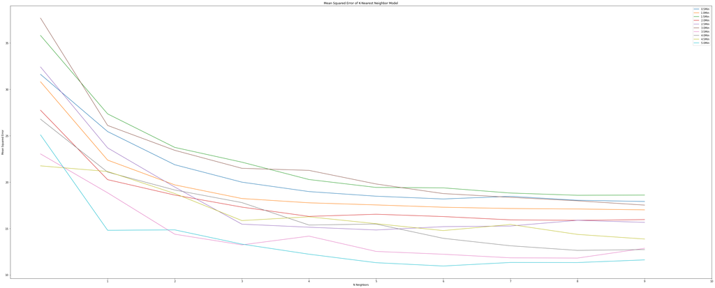

```python
# plot mse of KNN
knn_collection_mse_df = pd.DataFrame(knn_collection_mse)

ax = knn_collection_mse_df.plot.line()
x_axis = list(range(1, max_neigh+1))
ax.set_xticks(x_axis)
ax.set_ylabel("Mean Squared Error")
ax.set_xlabel("N Neighbors")
ax.set_title("Mean Squared Error of K-Nearest Neighbor Model")
```

```python
# find best KNN model
# the number n of neighbors that yields the lowest mse of each time frame
n_mse = knn_collection_mse_df.apply(pd.Series.argmin).mode().iloc[0]
best_model['KNN'] = knn_collection[list(candles_collection.keys())[knn_collection_mse_df.iloc[n_mse, :].argmin()]][n_mse]
print(
  n_mse+1, # N neighbors
  list(candles_collection.keys())[knn_collection_mse_df.iloc[n_mse, :].argmin()], # label
  knn_collection_mse_df.iloc[n_mse, :].min() # mse
)
```

```
9 5.0Min 11.331472059779122
```

## Support Vector Machine

```python
# Support Vector Machine
svm_collection_mse = {label: [] for label in candles_collection.keys()}

for label, model in svm_collection.items():
  # predict on test data
  X_train, X_test, y_train, y_test = candles_collection[label]
  y_pred = model.predict(X_test)
  # evaluation
  mse = mean_squared_error(y_test, y_pred)
  svm_collection_mse[label] = mse
```

```python
# create dataframe for mse of svm
svm_collection_mse_df = pd.DataFrame(svm_collection_mse, index=[0])
svm_collection_mse_df
```

|  | 0.5Min | 1.0Min | 1.5Min | 2.0Min | 2.5Min | 3.0Min | 3.5Min | 4.0Min | 4.5Min | 5.0Min |
| --- | --- | --- | --- | --- | --- | --- | --- | --- | --- | --- |
| 0 | 18.166681 | 15.570171 | 17.203873 | 16.765849 | 16.737788 | 17.1517 | 13.828462 | 13.880865 | 15.923338 | 11.879533 |

```python
# find best svm model
best_model['SVM'] = svm_collection[svm_collection_mse_df.idxmin(axis=1).iloc[0]]
svm_collection_mse_df.min(axis=1)
```

```
0    11.879533
dtype: float64
```

## Ensemble Learning

```python
# Combine K-Nearest Neighbor and Support Vector Machine
def ensemble(data):
  knn = best_model['KNN'].predict(data).flatten()
  svm = best_model['SVM'].predict(data)
  df = pd.DataFrame(data={'KNN': knn, 'SVM': svm})
  return df.mean(axis=1)
```

```python
X_train, X_test, y_train, y_test = candles_collection[label]
y_pred = ensemble(X_test)
en_mse = mean_squared_error(y_test, y_pred)
en_mse
```

```
10.811889567373099
```

# Investment Strategy